# Task 2: Weather Data

Balkiss Tekaya, Sirine El Feki, Tasnim Tekaya

12/12/2021

load the required libraries

```r
library(ggplot2)
library(dplyr)
library(sf)
library(mapview)#the last 2 to visualize the obs on a map
library(tidyr)
```

load the dataset from github

```r
df <- read.csv("https://raw.githubusercontent.com/enricoromano/Python-and-R-project-/baea5d52f994c4f8de0669dc4ca72aac6b0d81f0/meteo.csv")
```

let’s check the dataset

```r
str(df)
```

```
## 'data.frame':    1008 obs. of  25 variables:
##  $ hourly.dewpoint_2m               : num  4.6 3.8 3.6 3.6 4 3.7 3.2 2.5 1.8 1.5 ...
##  $ hourly.apparent_temperature      : num  3.2 1.9 1.6 1.7 2 1.9 1.4 1.2 0.2 -0.1 ...
##  $ hourly.precipitation             : num  0 0 0 0 0 0 0 0 0 0 ...
##  $ hourly.time                      : chr  "2021-11-22T00:00" "2021-11-22T01:00" "2021-11-22T02:00" "2021-11-22T03:00" ...
##  $ hourly.freezinglevel_height      : int  1032 1013 970 950 846 775 747 761 722 725 ...
##  $ hourly.snow_height               : int  0 0 0 0 0 0 0 0 0 0 ...
##  $ hourly.relativehumidity_2m       : int  95 96 97 95 95 94 91 88 89 88 ...
##  $ hourly.temperature_2m            : num  5.3 4.4 4.1 4.4 4.6 4.7 4.5 4.4 3.5 3.3 ...
##  $ hourly.pressure_msl              : num  1014 1016 1016 1017 1017 ...
##  $ hourly.weathercode               : int  2 3 2 3 3 3 3 3 2 1 ...
##  $ generationtime_ms                : num  2.87 2.87 2.87 2.87 2.87 ...
##  $ longitude                        : num  13.4 13.4 13.4 13.4 13.4 ...
##  $ hourly_units.snow_height         : chr  "m" "m" "m" "m" ...
##  $ hourly_units.freezinglevel_height: chr  "m" "m" "m" "m" ...
##  $ hourly_units.apparent_temperature: chr  "Â°C" "Â°C" "Â°C" "Â°C" ...
##  $ hourly_units.pressure_msl        : chr  "hPa" "hPa" "hPa" "hPa" ...
##  $ hourly_units.time                : chr  "iso8601" "iso8601" "iso8601" "iso8601" ...
##  $ hourly_units.temperature_2m      : chr  "Â°C" "Â°C" "Â°C" "Â°C" ...
##  $ hourly_units.precipitation       : chr  "mm" "mm" "mm" "mm" ...
##  $ hourly_units.dewpoint_2m         : chr  "Â°C" "Â°C" "Â°C" "Â°C" ...
##  $ hourly_units.relativehumidity_2m : chr  "%" "%" "%" "%" ...
##  $ hourly_units.weathercode         : chr  "wmo code" "wmo code" "wmo code" "wmo code" ...
##  $ elevation                        : num  44.8 44.8 44.8 44.8 44.8 ...
##  $ latitude                         : num  52.5 52.5 52.5 52.5 52.5 ...
##  $ utc_offset_seconds               : int  3600 3600 3600 3600 3600 3600 3600 3600 3600 3600 ...
```

do we have any NAs, none in our case

```r
any(is.na(df))
```

```
## [1] FALSE
```

let’s see how many locations we have it seems we have 6 locations in total, with 168 record for each place so we have a week (per hour) of records per location

```r
table(df$longitude)
```

```
##
##          -74 -0.120000124    2.3599997         12.5    13.419998      139.625
##          168          168          168          168          168          168
```

```r
table(df$latitude)
```

```
##
## 35.625  40.75 41.875  48.86   51.5  52.52
##    168    168    168    168    168    168
```

we visualize our observations on a map we subset a dataframe based only on the latitude & longitude

```r
locations = df %>%
  select(latitude, longitude)
```

now we create a sf object  
In the crs argument, we indicate that we want the longitude and latitude to be plotted using the World Geographic System 1984 projection,which is referenced as European Petroleum Survey Group (EPSG) 4326.

```r
locations_sf <- st_as_sf(locations, coords = c("longitude","latitude"), crs = 4326)
```

Let’s view our data !  
* we have 4 locations in Europe:  
Rome, Paris, Berlin & London  
* one in New York  
* one in Tokyo

```r
mapview(locations_sf)
```

[interactive chart not shown]

### DATA CLEANING

we transform hourly.time variable into two variables “day” and “time”

```r
df = df %>%
  separate(hourly.time, into = c("date", "time"), sep = "T")
```

we also see that many variables are simply the unit of some other variables  
select only the unit variables

```r
unit = df %>%
  select(contains('hourly_units'))
```

We then check to see the unique values in each. Each one contains only one unit. We see all the temperatures are in °C, heights in m, precipitations in mm timezone is iso8601, relative humidity in %, and pressure in hPa

```r
unique(unit)
```

```
##   hourly_units.snow_height hourly_units.freezinglevel_height
## 1                        m                                 m
##   hourly_units.apparent_temperature hourly_units.pressure_msl hourly_units.time
## 1                               Â°C                       hPa           iso8601
##   hourly_units.temperature_2m hourly_units.precipitation
## 1                         Â°C                         mm
##   hourly_units.dewpoint_2m hourly_units.relativehumidity_2m
## 1                      Â°C                                %
##   hourly_units.weathercode
## 1                 wmo code
```

We can drop all of these columns as they bring no value added to the analysis since they are all in the same unit

```r
df = df %>%
  select(-contains('hourly_units'))
```

### DATA VISUALIZATION

We can visualize the evolution of the temperature over the week (per hour) for each location  
First we subset that location from the dataset (based on the map)  
We create a subset for each city

```r
berlin = df %>%
  filter(latitude == 52.52, longitude == 13.4199980)

rome = df %>%
  filter(latitude == 41.875, longitude == 12.5)

london = df %>%
  filter(latitude == 51.5, longitude == -0.120000124)

paris = df %>%
  filter(latitude == 48.86, longitude == 2.3599997)

tokyo = df %>%
  filter(latitude == 35.625, longitude == 139.625)

newyork = df %>%
  filter(latitude == 40.75, longitude == -74)
```

Now we visualize the temperatures (per hour) for the whole week per city  
Each line represents a day in the week of 22/11 - 28/11  
We see that 22/11 is the hottest day in most plots for all the cities and that the temperature is decreasing with time

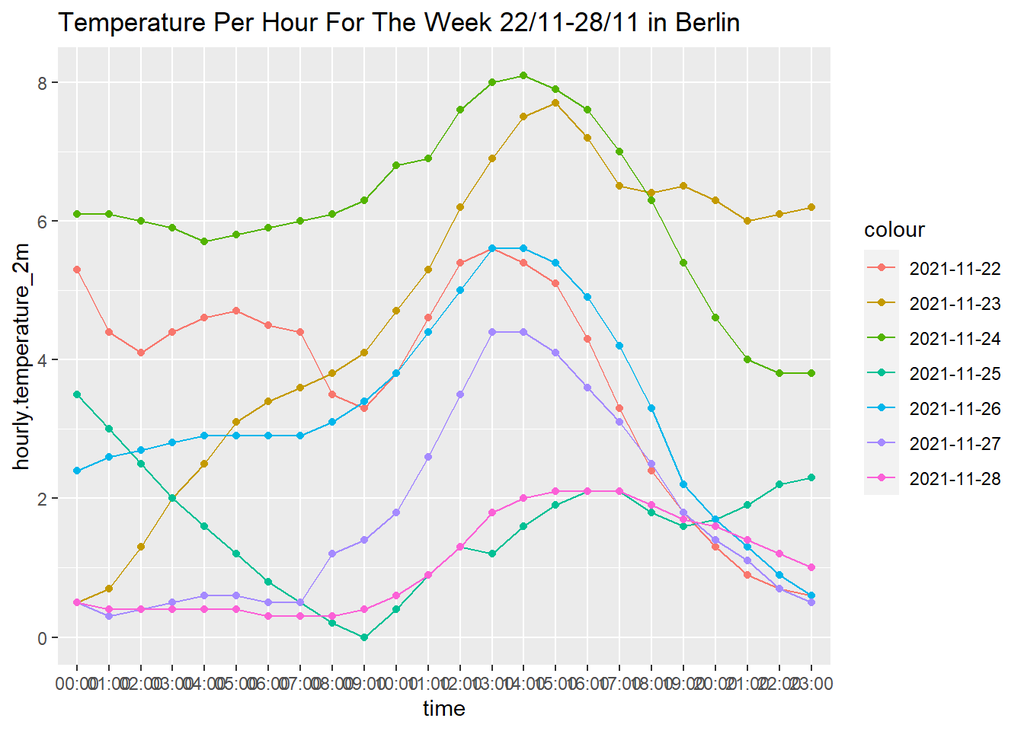

```r
#berlin
ggplot() +
  geom_point(data = berlin[c(1:24),], mapping = aes(x = time, y = hourly.temperature_2m, color="2021-11-22")) +
  geom_line(data = berlin[c(1:24),], mapping = aes(x = time, y = hourly.temperature_2m, group=1, color="2021-11-22")) +
  geom_point(data = berlin[c(25:48),], mapping = aes(x = time, y = hourly.temperature_2m, color="2021-11-23")) +
  geom_line(data = berlin[c(25:48),], mapping = aes(x = time, y = hourly.temperature_2m, group=1, color="2021-11-23"))+
  geom_point(data = berlin[c(49:72),], mapping = aes(x = time, y = hourly.temperature_2m, color="2021-11-24")) +
  geom_line(data = berlin[c(49:72),], mapping = aes(x = time, y = hourly.temperature_2m, group=1, color="2021-11-24")) +
  geom_point(data = berlin[c(73:96),], mapping = aes(x = time, y = hourly.temperature_2m, color="2021-11-25")) +
  geom_line(data = berlin[c(73:96),], mapping = aes(x = time, y = hourly.temperature_2m, group=1, color="2021-11-25"))+
  geom_point(data = berlin[c(97:120),], mapping = aes(x = time, y = hourly.temperature_2m, color="2021-11-26")) +
  geom_line(data = berlin[c(97:120),], mapping = aes(x = time, y = hourly.temperature_2m, group=1, color="2021-11-26")) +
  geom_point(data = berlin[c(121:144),], mapping = aes(x = time, y = hourly.temperature_2m, color="2021-11-27")) +
  geom_line(data = berlin[c(121:144),], mapping = aes(x = time, y = hourly.temperature_2m, group=1, color="2021-11-27"))+
  geom_point(data = berlin[c(145:168),], mapping = aes(x = time, y = hourly.temperature_2m, color="2021-11-28")) +
  geom_line(data = berlin[c(145:168),], mapping = aes(x = time, y = hourly.temperature_2m, group=1, color="2021-11-28")) +
  ggtitle("Temperature Per Hour For The Week 22/11-28/11 in Berlin")
```

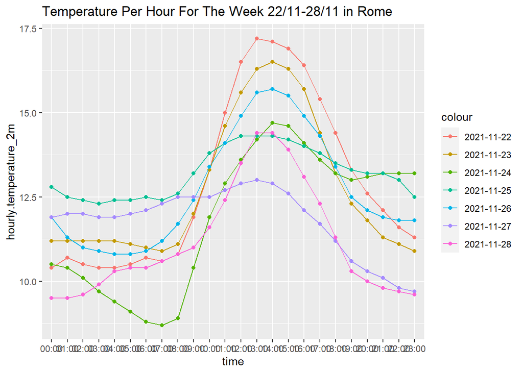

```r
#rome
ggplot() +
  geom_point(data = rome[c(1:24),], mapping = aes(x = time, y = hourly.temperature_2m, color="2021-11-22")) +
  geom_line(data = rome[c(1:24),], mapping = aes(x = time, y = hourly.temperature_2m, group=1, color="2021-11-22")) +
  geom_point(data = rome[c(25:48),], mapping = aes(x = time, y = hourly.temperature_2m, color="2021-11-23")) +
  geom_line(data = rome[c(25:48),], mapping = aes(x = time, y = hourly.temperature_2m, group=1, color="2021-11-23"))+
  geom_point(data = rome[c(49:72),], mapping = aes(x = time, y = hourly.temperature_2m, color="2021-11-24")) +
  geom_line(data = rome[c(49:72),], mapping = aes(x = time, y = hourly.temperature_2m, group=1, color="2021-11-24")) +
  geom_point(data = rome[c(73:96),], mapping = aes(x = time, y = hourly.temperature_2m, color="2021-11-25")) +
  geom_line(data = rome[c(73:96),], mapping = aes(x = time, y = hourly.temperature_2m, group=1, color="2021-11-25"))+
  geom_point(data = rome[c(97:120),], mapping = aes(x = time, y = hourly.temperature_2m, color="2021-11-26")) +
  geom_line(data = rome[c(97:120),], mapping = aes(x = time, y = hourly.temperature_2m, group=1, color="2021-11-26")) +
  geom_point(data = rome[c(121:144),], mapping = aes(x = time, y = hourly.temperature_2m, color="2021-11-27")) +
  geom_line(data = rome[c(121:144),], mapping = aes(x = time, y = hourly.temperature_2m, group=1, color="2021-11-27"))+
  geom_point(data = rome[c(145:168),], mapping = aes(x = time, y = hourly.temperature_2m, color="2021-11-28")) +
  geom_line(data = rome[c(145:168),], mapping = aes(x = time, y = hourly.temperature_2m, group=1, color="2021-11-28")) +
  ggtitle("Temperature Per Hour For The Week 22/11-28/11 in Rome")
```

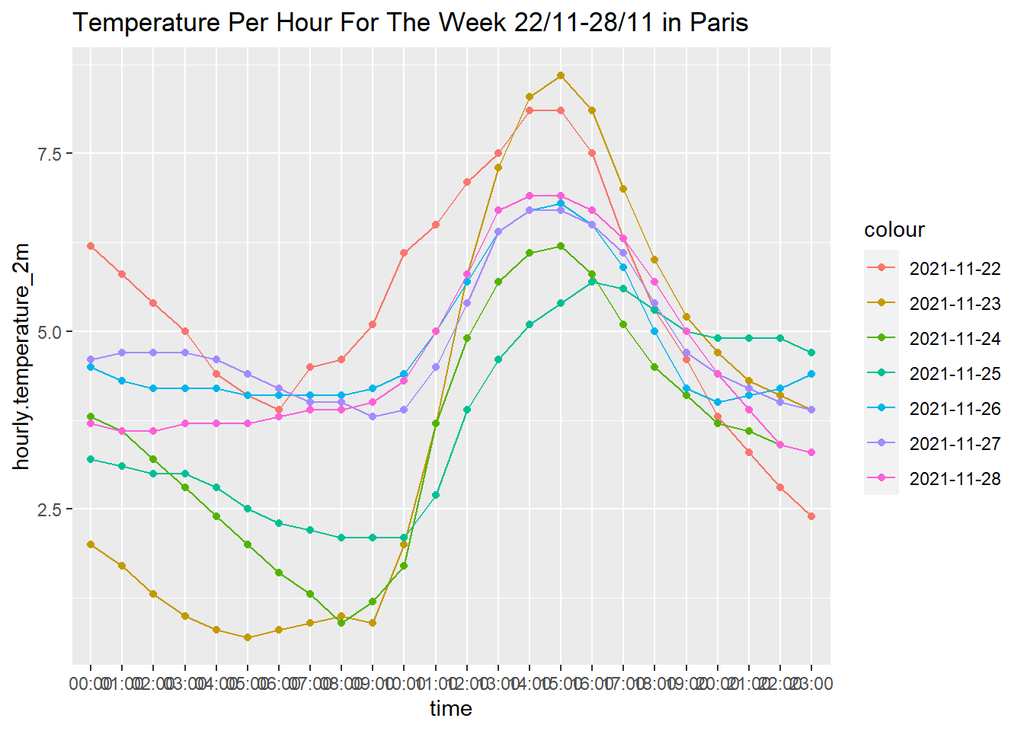

```r
#paris
ggplot() +
  geom_point(data = paris[c(1:24),], mapping = aes(x = time, y = hourly.temperature_2m, color="2021-11-22")) +
  geom_line(data = paris[c(1:24),], mapping = aes(x = time, y = hourly.temperature_2m, group=1, color="2021-11-22")) +
  geom_point(data = paris[c(25:48),], mapping = aes(x = time, y = hourly.temperature_2m, color="2021-11-23")) +
  geom_line(data = paris[c(25:48),], mapping = aes(x = time, y = hourly.temperature_2m, group=1, color="2021-11-23"))+
  geom_point(data = paris[c(49:72),], mapping = aes(x = time, y = hourly.temperature_2m, color="2021-11-24")) +
  geom_line(data = paris[c(49:72),], mapping = aes(x = time, y = hourly.temperature_2m, group=1, color="2021-11-24")) +
  geom_point(data = paris[c(73:96),], mapping = aes(x = time, y = hourly.temperature_2m, color="2021-11-25")) +
  geom_line(data = paris[c(73:96),], mapping = aes(x = time, y = hourly.temperature_2m, group=1, color="2021-11-25"))+
  geom_point(data = paris[c(97:120),], mapping = aes(x = time, y = hourly.temperature_2m, color="2021-11-26")) +
  geom_line(data = paris[c(97:120),], mapping = aes(x = time, y = hourly.temperature_2m, group=1, color="2021-11-26")) +
  geom_point(data = paris[c(121:144),], mapping = aes(x = time, y = hourly.temperature_2m, color="2021-11-27")) +
  geom_line(data = paris[c(121:144),], mapping = aes(x = time, y = hourly.temperature_2m, group=1, color="2021-11-27"))+
  geom_point(data = paris[c(145:168),], mapping = aes(x = time, y = hourly.temperature_2m, color="2021-11-28")) +
  geom_line(data = paris[c(145:168),], mapping = aes(x = time, y = hourly.temperature_2m, group=1, color="2021-11-28")) +
  ggtitle("Temperature Per Hour For The Week 22/11-28/11 in Paris")
```

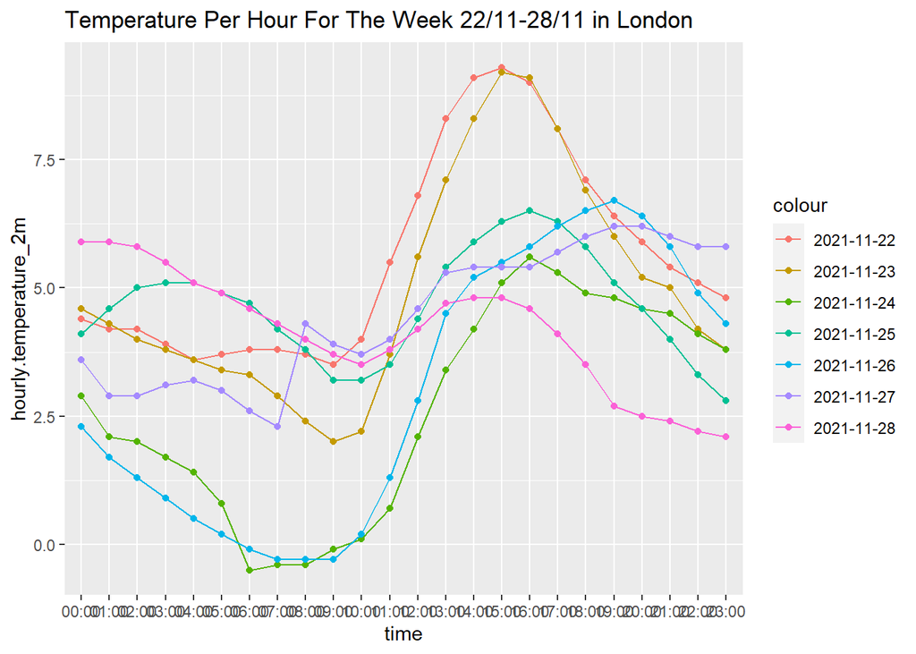

```r
#london
ggplot() +
  geom_point(data = london[c(1:24),], mapping = aes(x = time, y = hourly.temperature_2m, color="2021-11-22")) +
  geom_line(data = london[c(1:24),], mapping = aes(x = time, y = hourly.temperature_2m, group=1, color="2021-11-22")) +
  geom_point(data = london[c(25:48),], mapping = aes(x = time, y = hourly.temperature_2m, color="2021-11-23")) +
  geom_line(data = london[c(25:48),], mapping = aes(x = time, y = hourly.temperature_2m, group=1, color="2021-11-23"))+
  geom_point(data = london[c(49:72),], mapping = aes(x = time, y = hourly.temperature_2m, color="2021-11-24")) +
  geom_line(data = london[c(49:72),], mapping = aes(x = time, y = hourly.temperature_2m, group=1, color="2021-11-24")) +
  geom_point(data = london[c(73:96),], mapping = aes(x = time, y = hourly.temperature_2m, color="2021-11-25")) +
  geom_line(data = london[c(73:96),], mapping = aes(x = time, y = hourly.temperature_2m, group=1, color="2021-11-25"))+
  geom_point(data = london[c(97:120),], mapping = aes(x = time, y = hourly.temperature_2m, color="2021-11-26")) +
  geom_line(data = london[c(97:120),], mapping = aes(x = time, y = hourly.temperature_2m, group=1, color="2021-11-26")) +
  geom_point(data = london[c(121:144),], mapping = aes(x = time, y = hourly.temperature_2m, color="2021-11-27")) +
  geom_line(data = london[c(121:144),], mapping = aes(x = time, y = hourly.temperature_2m, group=1, color="2021-11-27"))+
  geom_point(data = london[c(145:168),], mapping = aes(x = time, y = hourly.temperature_2m, color="2021-11-28")) +
  geom_line(data = london[c(145:168),], mapping = aes(x = time, y = hourly.temperature_2m, group=1, color="2021-11-28")) +
  ggtitle("Temperature Per Hour For The Week 22/11-28/11 in London")
```

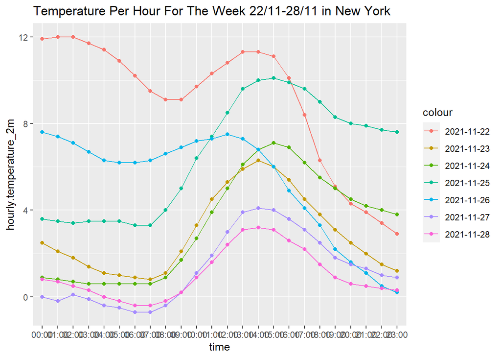

```r
#newyork
ggplot() +
  geom_point(data = newyork[c(1:24),], mapping = aes(x = time, y = hourly.temperature_2m, color="2021-11-22")) +
  geom_line(data = newyork[c(1:24),], mapping = aes(x = time, y = hourly.temperature_2m, group=1, color="2021-11-22")) +
  geom_point(data = newyork[c(25:48),], mapping = aes(x = time, y = hourly.temperature_2m, color="2021-11-23")) +
  geom_line(data = newyork[c(25:48),], mapping = aes(x = time, y = hourly.temperature_2m, group=1, color="2021-11-23"))+
  geom_point(data = newyork[c(49:72),], mapping = aes(x = time, y = hourly.temperature_2m, color="2021-11-24")) +
  geom_line(data = newyork[c(49:72),], mapping = aes(x = time, y = hourly.temperature_2m, group=1, color="2021-11-24")) +
  geom_point(data = newyork[c(73:96),], mapping = aes(x = time, y = hourly.temperature_2m, color="2021-11-25")) +
  geom_line(data = newyork[c(73:96),], mapping = aes(x = time, y = hourly.temperature_2m, group=1, color="2021-11-25"))+
  geom_point(data = newyork[c(97:120),], mapping = aes(x = time, y = hourly.temperature_2m, color="2021-11-26")) +
  geom_line(data = newyork[c(97:120),], mapping = aes(x = time, y = hourly.temperature_2m, group=1, color="2021-11-26")) +
  geom_point(data = newyork[c(121:144),], mapping = aes(x = time, y = hourly.temperature_2m, color="2021-11-27")) +
  geom_line(data = newyork[c(121:144),], mapping = aes(x = time, y = hourly.temperature_2m, group=1, color="2021-11-27"))+
  geom_point(data = newyork[c(145:168),], mapping = aes(x = time, y = hourly.temperature_2m, color="2021-11-28")) +
  geom_line(data = newyork[c(145:168),], mapping = aes(x = time, y = hourly.temperature_2m, group=1, color="2021-11-28")) +
  ggtitle("Temperature Per Hour For The Week 22/11-28/11 in New York")
```

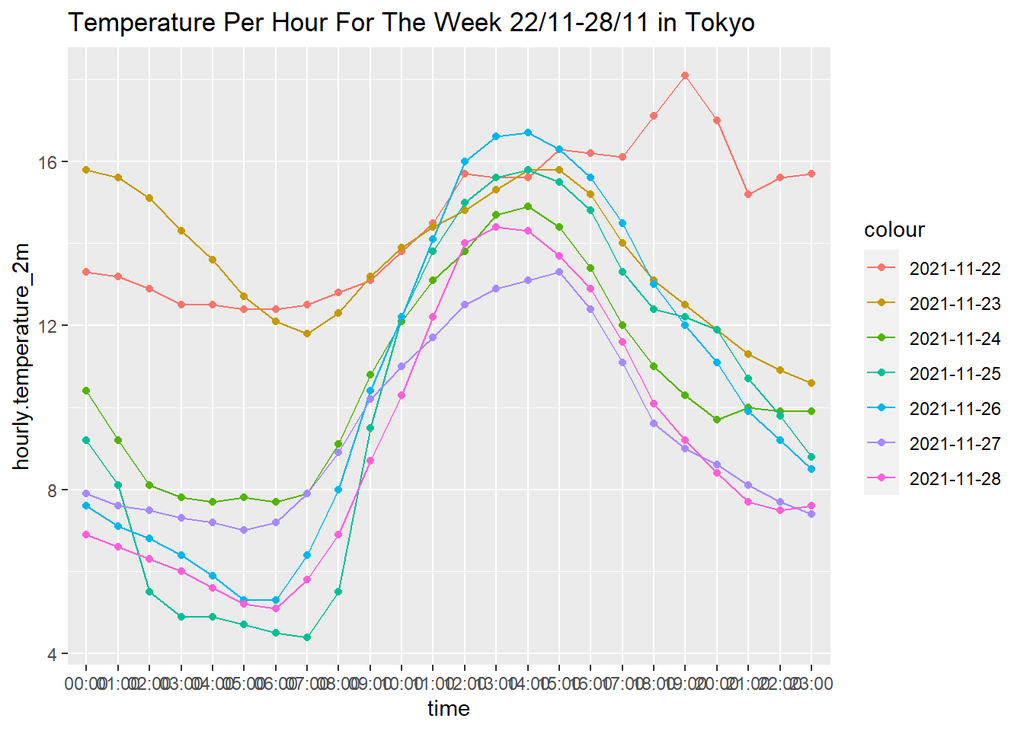

```r
#tokyo
ggplot() +
  geom_point(data = tokyo[c(1:24),], mapping = aes(x = time, y = hourly.temperature_2m, color="2021-11-22")) +
  geom_line(data = tokyo[c(1:24),], mapping = aes(x = time, y = hourly.temperature_2m, group=1, color="2021-11-22")) +
  geom_point(data = tokyo[c(25:48),], mapping = aes(x = time, y = hourly.temperature_2m, color="2021-11-23")) +
  geom_line(data = tokyo[c(25:48),], mapping = aes(x = time, y = hourly.temperature_2m, group=1, color="2021-11-23"))+
  geom_point(data = tokyo[c(49:72),], mapping = aes(x = time, y = hourly.temperature_2m, color="2021-11-24")) +
  geom_line(data = tokyo[c(49:72),], mapping = aes(x = time, y = hourly.temperature_2m, group=1, color="2021-11-24")) +
  geom_point(data = tokyo[c(73:96),], mapping = aes(x = time, y = hourly.temperature_2m, color="2021-11-25")) +
  geom_line(data = tokyo[c(73:96),], mapping = aes(x = time, y = hourly.temperature_2m, group=1, color="2021-11-25"))+
  geom_point(data = tokyo[c(97:120),], mapping = aes(x = time, y = hourly.temperature_2m, color="2021-11-26")) +
  geom_line(data = tokyo[c(97:120),], mapping = aes(x = time, y = hourly.temperature_2m, group=1, color="2021-11-26")) +
  geom_point(data = tokyo[c(121:144),], mapping = aes(x = time, y = hourly.temperature_2m, color="2021-11-27")) +
  geom_line(data = tokyo[c(121:144),], mapping = aes(x = time, y = hourly.temperature_2m, group=1, color="2021-11-27"))+
  geom_point(data = tokyo[c(145:168),], mapping = aes(x = time, y = hourly.temperature_2m, color="2021-11-28")) +
  geom_line(data = tokyo[c(145:168),], mapping = aes(x = time, y = hourly.temperature_2m, group=1, color="2021-11-28"))+
  ggtitle("Temperature Per Hour For The Week 22/11-28/11 in Tokyo")
```

Let us aggregate the hours and calculate the average temperature per day for the cities  
We also add the apparent (felt) temperature to compare it to the real temp  
We also add average precipitation

```r
#berlin
by_day_berlin = group_by(berlin, date)
summarised_berlin = summarise(by_day_berlin, temp = mean(hourly.temperature_2m), apparent_temp=mean(hourly.apparent_temperature), precip= mean(hourly.precipitation))

#rome
by_day_rome = group_by(rome, date)
summarised_rome = summarise(by_day_rome, temp = mean(hourly.temperature_2m), apparent_temp=mean(hourly.apparent_temperature),precip = mean(hourly.precipitation))

#paris
by_day_paris = group_by(paris, date)
summarised_paris = summarise(by_day_paris, temp = mean(hourly.temperature_2m), apparent_temp=mean(hourly.apparent_temperature), precip= mean(hourly.precipitation))

#london
by_day_london = group_by(london, date)
summarised_london = summarise(by_day_london, temp = mean(hourly.temperature_2m), apparent_temp=mean(hourly.apparent_temperature), precip= mean(hourly.precipitation))

#newyork
by_day_newyork = group_by(newyork, date)
summarised_newyork = summarise(by_day_newyork, temp = mean(hourly.temperature_2m), apparent_temp=mean(hourly.apparent_temperature), precip= mean(hourly.precipitation))

#tokyo
by_day_tokyo = group_by(tokyo, date)
summarised_tokyo = summarise(by_day_tokyo, temp = mean(hourly.temperature_2m), apparent_temp=mean(hourly.apparent_temperature), precip= mean(hourly.precipitation))
```

We plot the evolution of the average temperature per day in each city

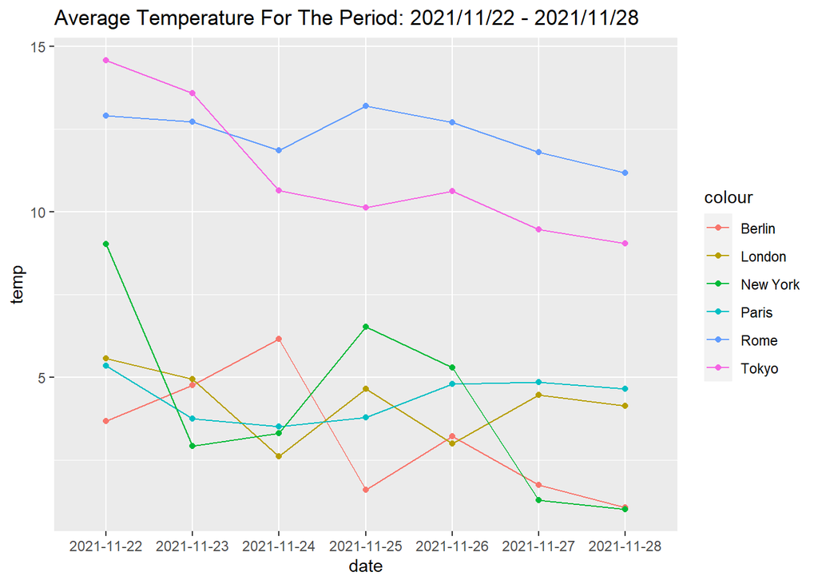

```r
ggplot()+
  geom_point(data = summarised_berlin, mapping = aes(x = date, y = temp, color="Berlin")) +
  geom_line(data = summarised_berlin, mapping = aes(x = date, y = temp, group=1, color="Berlin")) +
  geom_point(data = summarised_rome, mapping = aes(x = date, y = temp, color="Rome")) +
  geom_line(data = summarised_rome, mapping = aes(x = date, y = temp, group=1, color="Rome")) +
  geom_point(data = summarised_london, mapping = aes(x = date, y = temp, color="London")) +
  geom_line(data = summarised_london, mapping = aes(x = date, y = temp, group=1, color="London")) +
  geom_point(data = summarised_paris, mapping = aes(x = date, y = temp, color="Paris")) +
  geom_line(data = summarised_paris, mapping = aes(x = date, y = temp, group=1, color="Paris"))+
  geom_point(data = summarised_tokyo, mapping = aes(x = date, y = temp, color="Tokyo")) +
  geom_line(data = summarised_tokyo, mapping = aes(x = date, y = temp, group=1, color="Tokyo"))+
  geom_point(data = summarised_newyork, mapping = aes(x = date, y = temp, color="New York")) +
  geom_line(data = summarised_newyork, mapping = aes(x = date, y = temp, group=1, color="New York"))+
  ggtitle("Average Temperature For The Period: 2021/11/22 - 2021/11/28 ")
```

We can also visualize their evolution one at a time & compare it to average felt temperature:

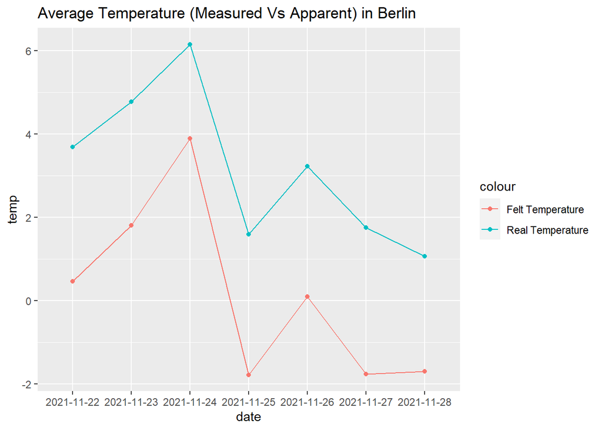

```r
#berlin
summarised_berlin %>%
  ggplot() +
  geom_point(mapping = aes(x = date, y = temp, color="Real Temperature")) +
  geom_line(mapping = aes(x = date, y = temp, group=1, color="Real Temperature")) +
  geom_point(mapping = aes(x = date, y = apparent_temp, color="Felt Temperature")) +
  geom_line(mapping = aes(x = date, y = apparent_temp, group=1, color="Felt Temperature")) +
  ggtitle("Average Temperature (Measured Vs Apparent) in Berlin")
```

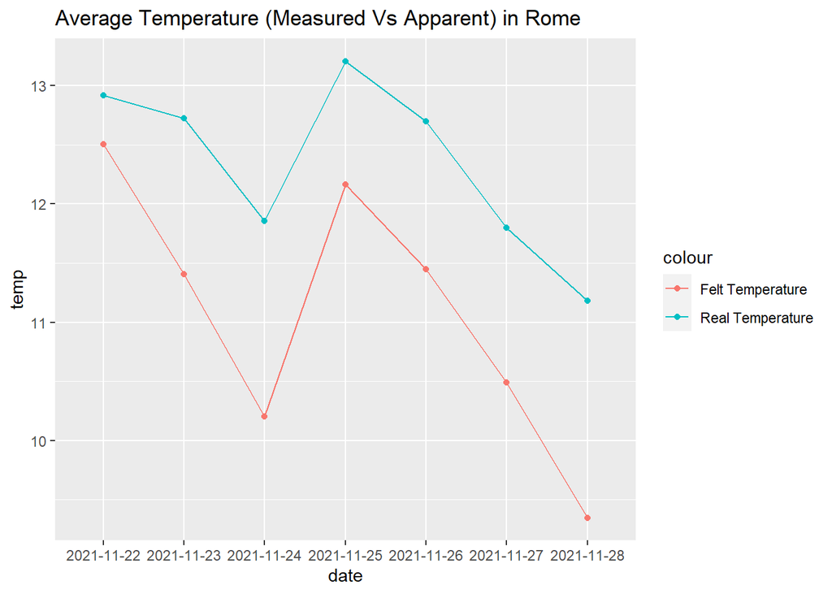

```r
#rome
summarised_rome %>%
  ggplot() +
  geom_point(mapping = aes(x = date, y = temp, color="Real Temperature")) +
  geom_line(mapping = aes(x = date, y = temp, group=1, color="Real Temperature")) +
  geom_point(mapping = aes(x = date, y = apparent_temp, color="Felt Temperature")) +
  geom_line(mapping = aes(x = date, y = apparent_temp, group=1, color="Felt Temperature")) +
  ggtitle("Average Temperature (Measured Vs Apparent) in Rome")
```

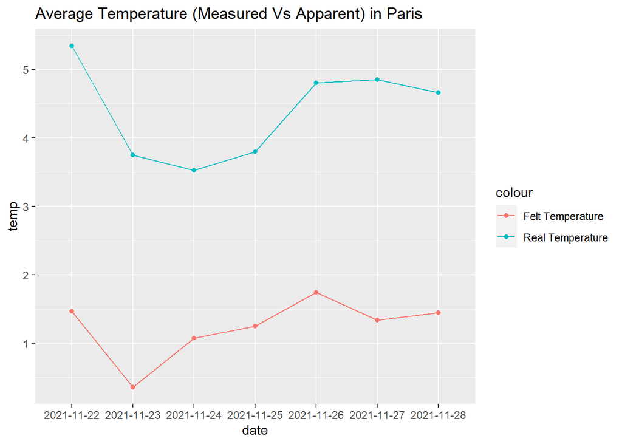

```r
#paris
summarised_paris %>%
  ggplot() +
  geom_point(mapping = aes(x = date, y = temp, color="Real Temperature")) +
  geom_line(mapping = aes(x = date, y = temp, group=1, color="Real Temperature")) +
  geom_point(mapping = aes(x = date, y = apparent_temp, color="Felt Temperature")) +
  geom_line(mapping = aes(x = date, y = apparent_temp, group=1, color="Felt Temperature")) +
  ggtitle("Average Temperature (Measured Vs Apparent) in Paris")
```

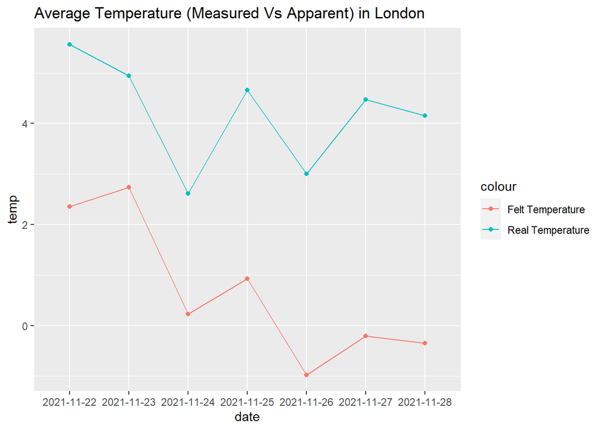

```r
#london
summarised_london %>%
  ggplot() +
  geom_point(mapping = aes(x = date, y = temp, color="Real Temperature")) +
  geom_line(mapping = aes(x = date, y = temp, group=1, color="Real Temperature")) +
  geom_point(mapping = aes(x = date, y = apparent_temp, color="Felt Temperature")) +
  geom_line(mapping = aes(x = date, y = apparent_temp, group=1, color="Felt Temperature")) +
  ggtitle("Average Temperature (Measured Vs Apparent) in London")
```

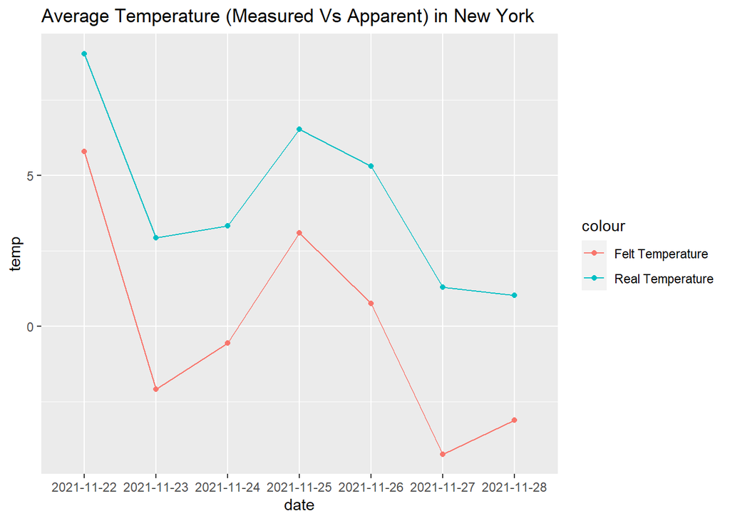

```r
#newyork
summarised_newyork %>%
  ggplot() +
  geom_point(mapping = aes(x = date, y = temp, color="Real Temperature")) +
  geom_line(mapping = aes(x = date, y = temp, group=1, color="Real Temperature")) +
  geom_point(mapping = aes(x = date, y = apparent_temp, color="Felt Temperature")) +
  geom_line(mapping = aes(x = date, y = apparent_temp, group=1, color="Felt Temperature")) +
  ggtitle("Average Temperature (Measured Vs Apparent) in New York")
```

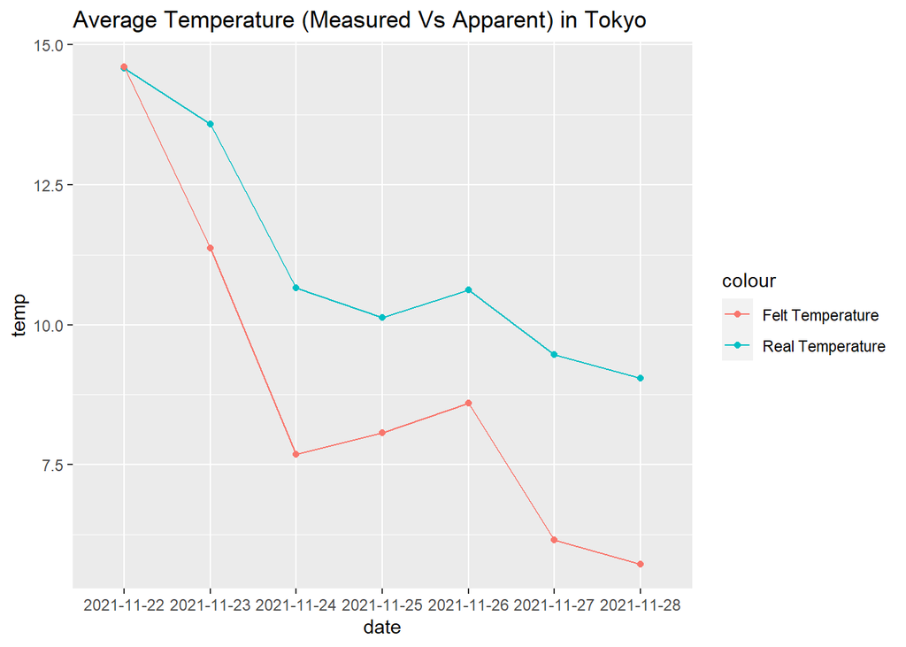

```r
#tokyo
summarised_tokyo %>%
  ggplot() +
  geom_point(mapping = aes(x = date, y = temp, color="Real Temperature")) +
  geom_line(mapping = aes(x = date, y = temp, group=1, color="Real Temperature")) +
  geom_point(mapping = aes(x = date, y = apparent_temp, color="Felt Temperature")) +
  geom_line(mapping = aes(x = date, y = apparent_temp, group=1, color="Felt Temperature")) +
  ggtitle("Average Temperature (Measured Vs Apparent) in Tokyo")
```

We can also visualize the average precipitation per day in each city

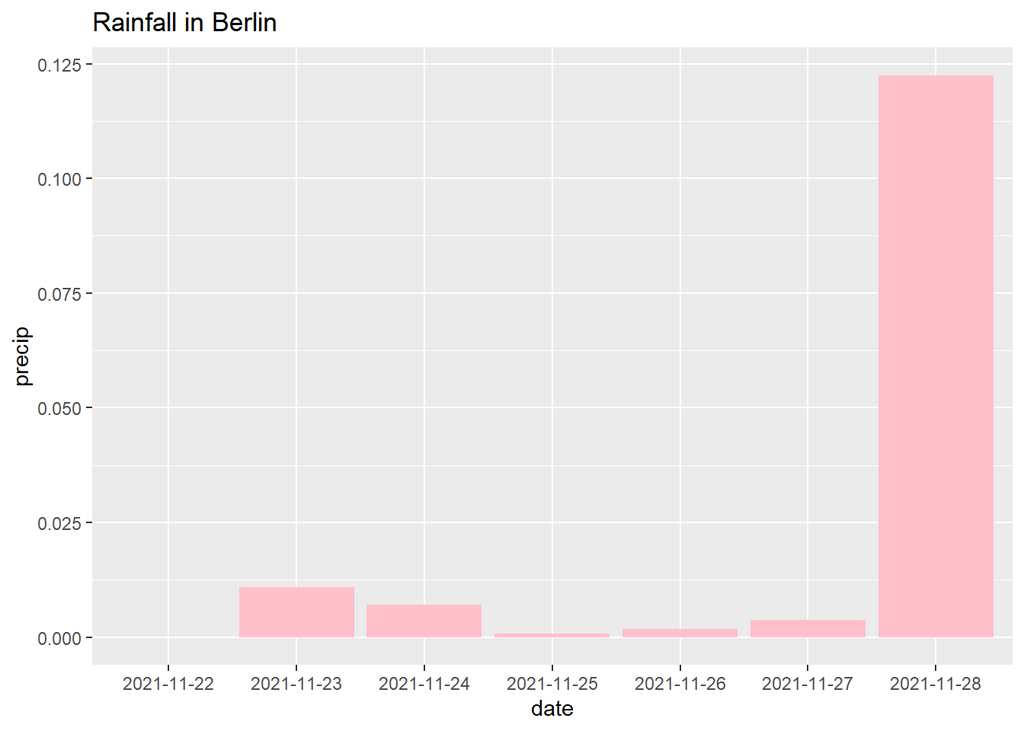

```r
#berlin
summarised_berlin %>%
  ggplot(mapping = aes(x = date, y = precip))+
    geom_bar(stat="identity",fill="pink") + ggtitle("Rainfall in Berlin")
```

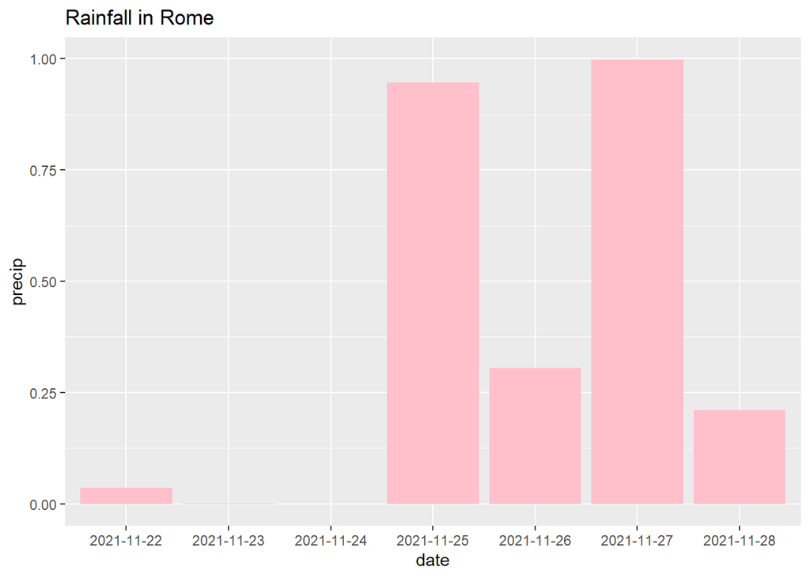

```r
#rome
summarised_rome %>%
  ggplot(mapping = aes(x = date, y = precip))+
  geom_bar(stat="identity",fill="pink") + ggtitle("Rainfall in Rome")
```

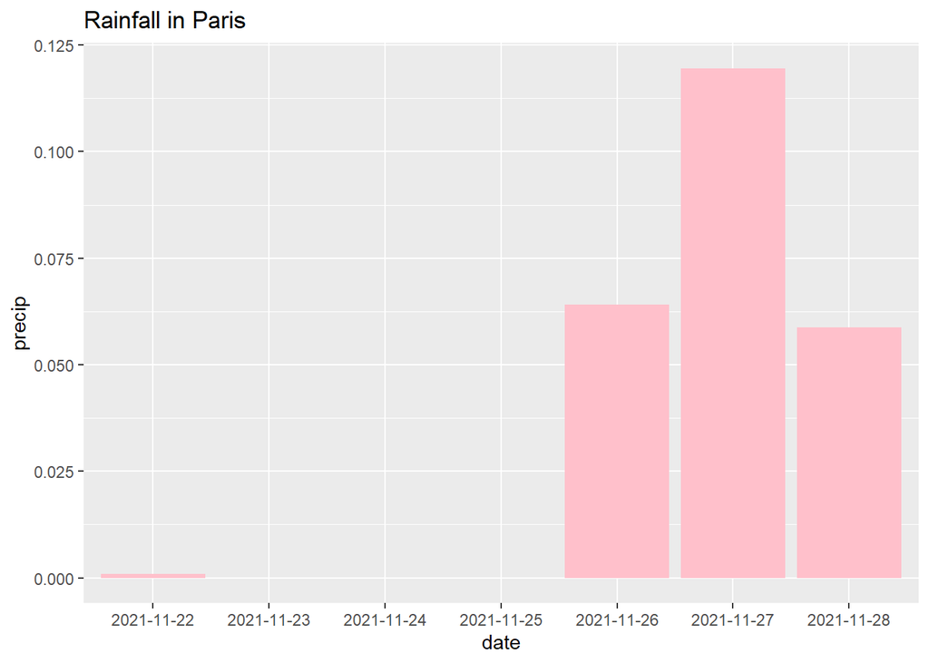

```r
#paris
summarised_paris %>%
  ggplot(mapping = aes(x = date, y = precip))+
  geom_bar(stat="identity",fill="pink") + ggtitle("Rainfall in Paris")
```

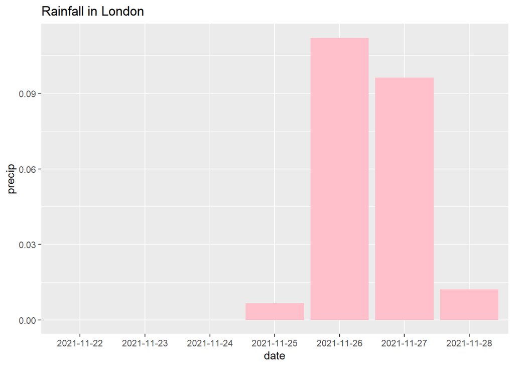

```r
#london
summarised_london %>%
  ggplot(mapping = aes(x = date, y = precip))+
  geom_bar(stat="identity",fill="pink") + ggtitle("Rainfall in London")
```

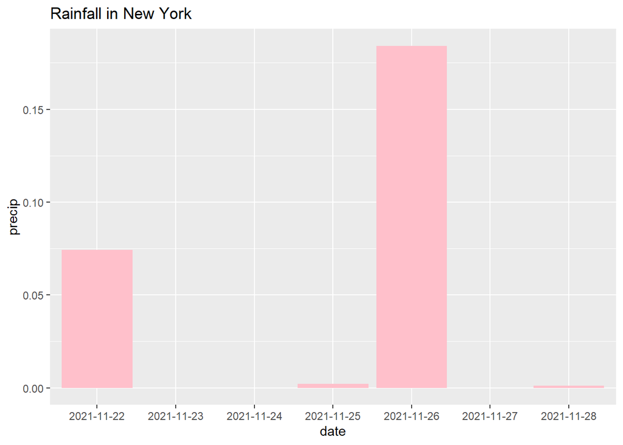

```r
#newyork
summarised_newyork %>%
  ggplot(mapping = aes(x = date, y = precip))+
  geom_bar(stat="identity",fill="pink") + ggtitle("Rainfall in New York")
```

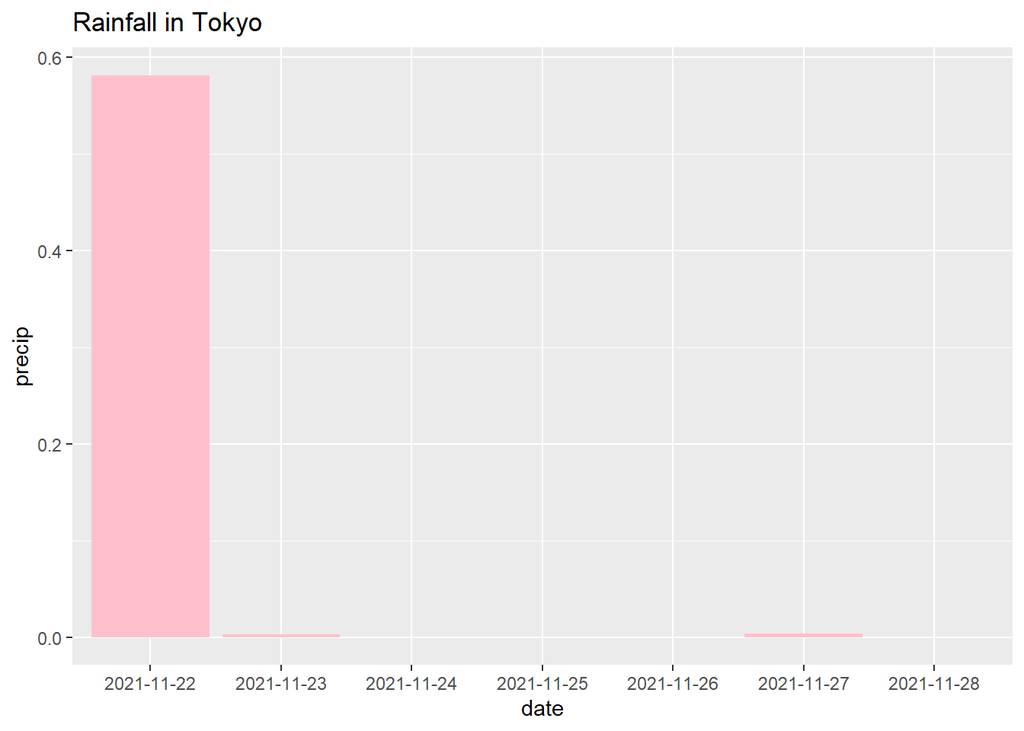

```r
#tokyo
summarised_tokyo %>%
  ggplot(mapping = aes(x = date, y = precip))+
  geom_bar(stat="identity",fill="pink") + ggtitle("Rainfall in Tokyo")
```